# INFO371 Take Home Final

Your name: Kishore Vasan Deadline: Tue, Mar 5 midnight

```python
import numpy
import pandas as pd
import seaborn as sns
import matplotlib.pyplot as plt
from sklearn.preprocessing import StandardScaler
from sklearn.model_selection import train_test_split
from sklearn.neighbors import KNeighborsClassifier
from sklearn.feature_extraction.text import CountVectorizer
from sklearn.feature_extraction.text import TfidfVectorizer
from sklearn.metrics import confusion_matrix
from sklearn import metrics
from sklearn.naive_bayes import MultinomialNB
from sklearn.datasets import load_boston
```

# 1. Regression

### 1.1

```python
boston = load_boston()
X = boston.data
y = boston.target

# check also boston.feature_names and other information
print('keys:', boston.keys())
print('feature names:', boston.feature_names)
print('data shape:', boston.data.shape)
print('target shape:', boston.target.shape)

boston_data = pd.DataFrame(boston.data)
boston_data.columns = boston.feature_names[:]
boston_data.head()
```

```
('keys:', ['data', 'feature_names', 'DESCR', 'target'])
('feature names:', array(['CRIM', 'ZN', 'INDUS', 'CHAS', 'NOX', 'RM', 'AGE', 'DIS', 'RAD',
       'TAX', 'PTRATIO', 'B', 'LSTAT'], dtype='|S7'))
('data shape:', (506, 13))
('target shape:', (506,))
```

|  | CRIM | ZN | INDUS | CHAS | NOX | RM | AGE | DIS | RAD | TAX | PTRATIO | B | LSTAT |
| --- | --- | --- | --- | --- | --- | --- | --- | --- | --- | --- | --- | --- | --- |
| 0 | 0.00632 | 18.0 | 2.31 | 0.0 | 0.538 | 6.575 | 65.2 | 4.0900 | 1.0 | 296.0 | 15.3 | 396.90 | 4.98 |
| 1 | 0.02731 | 0.0 | 7.07 | 0.0 | 0.469 | 6.421 | 78.9 | 4.9671 | 2.0 | 242.0 | 17.8 | 396.90 | 9.14 |
| 2 | 0.02729 | 0.0 | 7.07 | 0.0 | 0.469 | 7.185 | 61.1 | 4.9671 | 2.0 | 242.0 | 17.8 | 392.83 | 4.03 |
| 3 | 0.03237 | 0.0 | 2.18 | 0.0 | 0.458 | 6.998 | 45.8 | 6.0622 | 3.0 | 222.0 | 18.7 | 394.63 | 2.94 |
| 4 | 0.06905 | 0.0 | 2.18 | 0.0 | 0.458 | 7.147 | 54.2 | 6.0622 | 3.0 | 222.0 | 18.7 | 396.90 | 5.33 |

```python
# All all features numeric?
print(boston_data.dtypes, "\n")
```

```
(CRIM       float64
ZN         float64
INDUS      float64
CHAS       float64
NOX        float64
RM         float64
AGE        float64
DIS        float64
RAD        float64
TAX        float64
PTRATIO    float64
B          float64
LSTAT      float64
dtype: object, '\n')
```

### 1.2

**kNN**:

Important hyperparameters: The k in k-nearest neighbors.

Strengths: fast, simple, and surprisingly flexible if you pre-process your data and engineer useful features.

Weaknesses: you need to specify the number of neighbors/clusters, which isn’t always easy to do

**Logistic**:

Important hyperparameters: The penalty and C in logistic.

Strengths: algorithm can be regularized to avoid overfitting, nice probabilistic interpretation

Weaknesses: tends to underperform when there are multiple or non-linear decision boundaries, can’t catch complexity

**Lasso**:

Important hyperparameters: alpha

Strengths: majorly used to prevent overfitting, sets less important predictors to zero and helps you with choosing the predictors that can be left out of the model

Weaknesses: In many analyses, it can be important to include *all* variables and not drop the ones that do not have significance in the predicting. They could be necessary control variables or their small effect could hold a large significance

**Ridge**:

Important hyperparameters:: alpha

Strengths: majorly used to prevent overfitting by adding a penalty to models that have too large coefficients

Weaknesses: Since it includes all the features, it is not very useful in case of exorbitantly high features, say in millions, as it will pose computational challenges.

**OLS**:

Important hyperparameters: there is none. The number/choice of features is not a hyperparameter, but can be viewed as a post processing or iterative tuning process.

Strengths: can be regularized to avoid overfitting, very useful on a huge amount of features where better algorithms suffer from overfitting

Weaknesses: performs poorly when there are non-linear relationships (can’t catch complexity)

# 2. Text Classification

### 2.1

```python
data = pd.read_csv("20-newsgroups.csv")
data.text = data.text.astype(str)
data.group = data.group.astype(str)
data.head()
```

|  | group | text |
| --- | --- | --- |
| 0 | alt.atheism | Atheist Resources Addresses of Atheist Organ... |
| 1 | alt.atheism | --BEGIN PGP SIGNED MESSAGE-- An Introduction ... |
| 2 | alt.atheism | In article (Charley Wingate) writes: Well, J... |
| 3 | alt.atheism | (..until kings become philosophers or philoso... |
| 4 | alt.atheism | In article (Bob McGwier) writes: [1] HOWEVER,... |

```python
#exploring data
print "shape of data:", data.shape
```

```
shape of data: (19997, 2)
```

```python
# test train split - 40% as test
train, test = train_test_split(data,test_size=0.80, random_state=42)
print("Length of train:", len(train))
print("Length of test:", len(test))
```

```
('Length of train:', 3999)
('Length of test:', 15998)
```

```python
# save the test file to use it later
test.to_csv(path_or_buf='test_news.csv', index = False)
del test
```

```python
train.group.unique()
```

```
array(['rec.autos', 'alt.atheism', 'comp.os.ms-windows.misc',
       'comp.windows.x', 'sci.med', 'rec.sport.baseball', 'misc.forsale',
       'sci.electronics', 'talk.religion.misc', 'sci.space', 'sci.crypt',
       'comp.sys.ibm.pc.hardware', 'rec.motorcycles',
       'soc.religion.christian', 'talk.politics.misc', 'comp.graphics',
       'comp.sys.mac.hardware', 'talk.politics.mideast',
       'talk.politics.guns', 'rec.sport.hockey'], dtype=object)
```

### 2.2

```python
#different accuracy
accuracy_final_list = []

def split_data_frame(df, num_chunks):
    listOfDf = list()
    chunk_size = len(df) // num_chunks
    for i in range(num_chunks):
        listOfDf.append(df[i*chunk_size:(i+1)*chunk_size])
    return listOfDf

def fitKNN(X_train, y_train,knn_k):
    global vectorizer, neigh
    # initialize the vectorizer
    vectorizer = CountVectorizer(min_df=0)

    # create the dictionary
    vectorizer.fit(X_train)

    # `fit` builds the vocabulary
    # transform your data into the BOW array
    X = vectorizer.transform(X_train).toarray()
    neigh = KNeighborsClassifier(n_neighbors = knn_k, algorithm = 'brute')
    neigh.fit(X, y_train)


def knn_cross_val(train, k, knn_k):
    print "k value:", knn_k
    chunks = split_data_frame(train, k)
    accuracy_list = []
    for chunk_df in chunks:
        tmp_train = train[~train.isin(chunk_df)]
        X_train = tmp_train.text.astype(str)
        y_train = tmp_train.group.astype(str)

        y_output = chunk_df.group

        fitKNN(X_train, y_train, knn_k)

        X_val = vectorizer.transform(chunk_df.text)
        predicted = neigh.predict(X_val)

        # finding accuracy
        accuracy = metrics.accuracy_score(y_output, predicted)*100
        accuracy_list.append(accuracy)

        print "Accuracy of the model:", accuracy
    print "Average accuracy:", numpy.mean(accuracy_list)
    print "------"
    accuracy_final_list.append(numpy.mean(accuracy_list))
```

```python
for tmp_k in range(1,11):
    knn_cross_val(train, 5,tmp_k)
```

```
k value: 1
Accuracy of the model: 23.52941176470588
Accuracy of the model: 25.15644555694618
Accuracy of the model: 28.53566958698373
Accuracy of the model: 25.65707133917397
Accuracy of the model: 25.406758448060074
Average accuracy: 25.657071339173967
------
k value: 2
Accuracy of the model: 22.02753441802253
Accuracy of the model: 21.526908635794744
Accuracy of the model: 23.404255319148938
Accuracy of the model: 23.779724655819777
Accuracy of the model: 21.777221526908637
Average accuracy: 22.503128911138923
------
k value: 3
Accuracy of the model: 21.90237797246558
Accuracy of the model: 19.774718397997496
Accuracy of the model: 22.65331664580726
Accuracy of the model: 21.401752190237797
Accuracy of the model: 19.899874843554443
Average accuracy: 21.12640801001252
------
k value: 4
Accuracy of the model: 19.524405506883603
Accuracy of the model: 17.897371714643302
Accuracy of the model: 20.77596996245307
Accuracy of the model: 20.150187734668336
Accuracy of the model: 18.1476846057572
Average accuracy: 19.299123904881107
------
k value: 5
Accuracy of the model: 18.773466833541928
Accuracy of the model: 17.897371714643302
Accuracy of the model: 21.777221526908637
Accuracy of the model: 20.02503128911139
Accuracy of the model: 19.02377972465582
Average accuracy: 19.499374217772218
------
```

[output cut: 25 more lines]

```
Accuracy of the model: 18.02252816020025
Accuracy of the model: 18.1476846057572
Accuracy of the model: 22.152690863579476
Accuracy of the model: 19.899874843554443
Accuracy of the model: 17.897371714643302
Average accuracy: 19.22403003754693
------
k value: 10
Accuracy of the model: 18.1476846057572
Accuracy of the model: 17.897371714643302
Accuracy of the model: 20.90112640801001
Accuracy of the model: 18.523153942428035
Accuracy of the model: 19.148936170212767
Average accuracy: 18.923654568210264
------
```

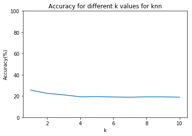

```python
plt.plot(range(1,11), accuracy_final_list)
plt.xlabel("k")
plt.ylabel("Accuracy(%)")
plt.title("Accuracy for different k values for knn")
plt.ylim(0,100)
plt.show()
```

From cross-validation on multiple k values, we get **k = 1** to have the highest accuracy!

### 2.3

```python
accuracy_final_list = []
def fitKNN_TFIDF(X_train, y_train,knn_k):
    global vectorizer, neigh
    # initialize the vectorizer
    vectorizer = TfidfVectorizer()

    # create the dictionary
    vectorizer.fit(X_train)

    # `fit` builds the vocabulary
    # transform your data into the BOW array
    X = vectorizer.transform(X_train).toarray()
    neigh = KNeighborsClassifier(n_neighbors = knn_k, algorithm = 'brute')
    neigh.fit(X, y_train)


def knn_cross_val_TFIDF(train, k, knn_k):
    print "k value:", knn_k
    chunks = split_data_frame(train, k)
    accuracy_list = []
    for chunk_df in chunks:
        tmp_train = train[~train.isin(chunk_df)]
        X_train = tmp_train.text.astype(str)
        y_train = tmp_train.group.astype(str)

        y_output = chunk_df.group

        fitKNN_TFIDF(X_train, y_train, knn_k)

        X_val = vectorizer.transform(chunk_df.text)
        predicted = neigh.predict(X_val)

        # finding accuracy
        accuracy = metrics.accuracy_score(y_output, predicted)*100
        accuracy_list.append(accuracy)

        print "Accuracy of the model:", accuracy
    print "Average accuracy:", numpy.mean(accuracy_list)
    print "------"
    accuracy_final_list.append(numpy.mean(accuracy_list))
```

```python
for tmp_k in range(1,11):
    knn_cross_val_TFIDF(train, 5,tmp_k)
```

```
k value: 1
Accuracy of the model: 60.70087609511889
Accuracy of the model: 57.947434292866085
Accuracy of the model: 59.94993742177722
Accuracy of the model: 57.1964956195244
Accuracy of the model: 57.446808510638306
Average accuracy: 58.64831038798498
------
k value: 2
Accuracy of the model: 55.94493116395495
Accuracy of the model: 50.563204005006256
Accuracy of the model: 51.18898623279099
Accuracy of the model: 48.310387984981226
Accuracy of the model: 50.438047559449316
Average accuracy: 51.28911138923654
------
k value: 3
Accuracy of the model: 54.69336670838548
Accuracy of the model: 50.438047559449316
Accuracy of the model: 50.68836045056321
Accuracy of the model: 47.934918648310386
Accuracy of the model: 49.93742177722152
Average accuracy: 50.73842302878599
------
k value: 4
Accuracy of the model: 55.319148936170215
Accuracy of the model: 49.436795994993744
Accuracy of the model: 50.31289111389236
Accuracy of the model: 47.80976220275344
Accuracy of the model: 48.56070087609512
Average accuracy: 50.28785982478097
------
k value: 5
Accuracy of the model: 54.943679599499376
Accuracy of the model: 48.685857321652065
Accuracy of the model: 48.81101376720901
Accuracy of the model: 46.808510638297875
Accuracy of the model: 49.68710888610764
Average accuracy: 49.78723404255319
------
```

[output cut: 25 more lines]

```
Accuracy of the model: 53.066332916145186
Accuracy of the model: 48.81101376720901
Accuracy of the model: 46.43304130162703
Accuracy of the model: 48.81101376720901
Accuracy of the model: 49.18648310387985
Average accuracy: 49.26157697121401
------
k value: 10
Accuracy of the model: 51.43929912390488
Accuracy of the model: 48.93617021276596
Accuracy of the model: 46.18272841051314
Accuracy of the model: 49.93742177722152
Accuracy of the model: 49.436795994993744
Average accuracy: 49.186483103879844
------
```

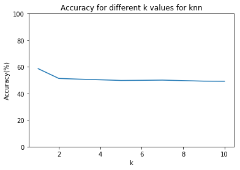

```python
plt.plot(range(1,11), accuracy_final_list)
plt.xlabel("k")
plt.ylabel("Accuracy(%)")
plt.title("Accuracy for different k values for knn")
plt.ylim(0,100)
plt.show()
```

Similar to last time with CountVectorizer, using TFIDF Vectorizer we get maximum accuracy at **k = 1**!

### 2.4

```python
accuracy_final_list = []

# fit NB for given train quotes and y train
def fitNB(X_train, y_train, alpha):
    global gnb, vectorizer
    # initialize the vectorizer
    vectorizer = CountVectorizer(min_df=0)

    # create the dictionary
    vectorizer.fit(X_train)

    # `fit` builds the vocabulary
    # transform your data into the BOW array
    X = vectorizer.transform(X_train).toarray()
    gnb = MultinomialNB(alpha = alpha)
    gnb.fit(X, y_train)

def knn_cross_val_TFIDF(train, k, knn_k):
    print "k value:", knn_k
    chunks = split_data_frame(train, k)
    accuracy_list = []
    for chunk_df in chunks:
        tmp_train = train[~train.isin(chunk_df)]
        X_train = tmp_train.text.astype(str)
        y_train = tmp_train.group.astype(str)

        y_output = chunk_df.group

        fitKNN_TFIDF(X_train, y_train, knn_k)

        X_val = vectorizer.transform(chunk_df.text)
        predicted = neigh.predict(X_val)

        # finding accuracy
        accuracy = metrics.accuracy_score(y_output, predicted)*100
        accuracy_list.append(accuracy)

        print "Accuracy of the model:", accuracy
    print "Average accuracy:", numpy.mean(accuracy_list)
    print "------"
    accuracy_final_list.append(numpy.mean(accuracy_list))

# create BOW for the quotes and predict
def nb_cross_val(train, num_chunks, alpha):
    print "alpha:", alpha
    chunks = split_data_frame(train, num_chunks)
    accuracy_list = []
    for chunk_df in chunks:
        tmp_train = train[~train.isin(chunk_df)]
        X_train = tmp_train.text.astype(str)
        y_train = tmp_train.group.astype(str)

        y_output = chunk_df.group

        fitNB(X_train, y_train, alpha)

        X_val = vectorizer.transform(chunk_df.text)
        predicted = gnb.predict(X_val)

        # finding accuracy
        accuracy = metrics.accuracy_score(y_output, predicted)*100
        accuracy_list.append(accuracy)

        print "Accuracy of the model:", accuracy
    print "Average accuracy:", numpy.mean(accuracy_list)
    print "------"
    accuracy_final_list.append(numpy.mean(accuracy_list))
```

```python
for tmp_alpha in numpy.linspace(0,1,11):
    nb_cross_val(train, 5,tmp_alpha)
```

```
alpha: 0.0
```

```
Accuracy of the model: 70.4630788485607
```

```
Accuracy of the model: 71.21401752190238
```

```
Accuracy of the model: 70.83854818523155
```

```
Accuracy of the model: 69.46182728410513
```

```
Accuracy of the model: 70.2127659574468
Average accuracy: 70.43804755944932
------
alpha: 0.1
Accuracy of the model: 73.21652065081352
Accuracy of the model: 72.96620775969961
Accuracy of the model: 74.71839799749687
Accuracy of the model: 76.09511889862328
Accuracy of the model: 71.96495619524406
Average accuracy: 73.79224030037547
------
alpha: 0.2
Accuracy of the model: 72.5907384230288
Accuracy of the model: 72.5907384230288
Accuracy of the model: 73.59198998748435
Accuracy of the model: 74.71839799749687
Accuracy of the model: 70.58823529411765
Average accuracy: 72.81602002503129
------
alpha: 0.30000000000000004
Accuracy of the model: 70.58823529411765
Accuracy of the model: 71.58948685857321
Accuracy of the model: 71.21401752190238
Accuracy of the model: 73.34167709637046
Accuracy of the model: 68.21026282853568
Average accuracy: 70.98873591989988
------
alpha: 0.4
Accuracy of the model: 68.8360450563204
Accuracy of the model: 70.33792240300374
Accuracy of the model: 68.71088861076345
Accuracy of the model: 71.96495619524406
Accuracy of the model: 65.33166458072591
Average accuracy: 69.0362953692115
------
alpha: 0.5
Accuracy of the model: 67.2090112640801
Accuracy of the model: 68.71088861076345
Accuracy of the model: 65.95744680851064
Accuracy of the model: 69.58698372966208
```

[output cut: 28 more lines]

```
Accuracy of the model: 57.571964956195245
Accuracy of the model: 58.072590738423024
Accuracy of the model: 56.69586983729662
Accuracy of the model: 58.19774718397998
Accuracy of the model: 53.94242803504381
Average accuracy: 56.896120150187734
------
alpha: 1.0
Accuracy of the model: 54.06758448060075
Accuracy of the model: 55.819774718397994
Accuracy of the model: 52.94117647058824
Accuracy of the model: 55.319148936170215
Accuracy of the model: 50.187734668335416
Average accuracy: 53.66708385481852
------
```

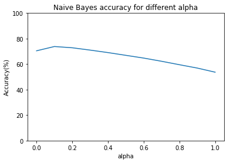

```python
plt.plot(numpy.linspace(0,1,11), accuracy_final_list)
plt.ylim(0,100)
plt.xlabel("alpha")
plt.ylabel("Accuracy(%)")
plt.title("Naive Bayes accuracy for different alpha")
plt.show()
```

After cross validation we observe that the maximum accuracy using Naive Bayes is found at **alpha = 0.1**

### 2.5

**Multinomial Naive Bayes showed the best accuracy using cross validation on our training dataset**. We also found that the optimal *smoothing value* that would give the highest accuracy is **0.1**.

Not suprisingly, it also had the **fastest run time out of all the models.**

### 2.6

```python
#load the data
test = pd.read_csv("test_news.csv")
test.text = test.text.astype(str)
test.group = test.group.astype(str)
```

```python
X_train = train.text
y_train = train.group

#transform train data
vectorizer = CountVectorizer(min_df=0)

# create the dictionary
vectorizer.fit(X_train)

# `fit` builds the vocabulary
# transform your data into the BOW array
X = vectorizer.transform(X_train).toarray()
gnb = MultinomialNB(alpha = 0.1)
gnb.fit(X, y_train)

#test the model accuracy on MultinomialNB with alpha = 0.1
X_test = vectorizer.transform(test.text)
y_test = test.group
predicted = gnb.predict(X_test)

# finding accuracy
accuracy = metrics.accuracy_score(y_test, predicted)*100
print "accuracy of the final model on test data:", accuracy
```

```
accuracy of the final model on test data: 76.1407675959495
```

```python
misclassified_idx = numpy.where(y_test != predicted)
misclassified_cases = numpy.array(y_test)[misclassified]
misclassified_cases
```

```
array(['comp.sys.ibm.pc.hardware', 'misc.forsale', 'rec.autos', ...,
       'soc.religion.christian', 'rec.autos', 'talk.religion.misc'],
      dtype=object)
```

```python
unique, counts = numpy.unique(misclassified_cases, return_counts=True)

print numpy.asarray((unique, counts)).T
```

```
[['alt.atheism' 240]
 ['comp.graphics' 153]
 ['comp.os.ms-windows.misc' 647]
 ['comp.sys.ibm.pc.hardware' 196]
 ['comp.sys.mac.hardware' 160]
 ['comp.windows.x' 185]
 ['misc.forsale' 245]
 ['rec.autos' 112]
 ['rec.motorcycles' 118]
 ['rec.sport.baseball' 74]
 ['rec.sport.hockey' 62]
 ['sci.crypt' 94]
 ['sci.electronics' 212]
 ['sci.med' 121]
 ['sci.space' 169]
 ['soc.religion.christian' 150]
 ['talk.politics.guns' 186]
 ['talk.politics.mideast' 103]
 ['talk.politics.misc' 209]
 ['talk.religion.misc' 381]]
```

**'comp.os.ms-windows.misc'** was the most misclassified out of all the misclassified cases

```python
print "number of cases of the above group in the training set:", len(train[train.group == 'comp.os.ms-windows.misc'])
print "proportion of training data with the group:", float(196)/float(len(train))
```

```
number of cases of the above group in the training set: 196
proportion of training data with the group: 0.0490122530633
```

As we can see, only about **5 percent** of the training data contained the most misclassified group. This may be a reason why our model was failing to accurately classify this group. If we had some form of selection criteria to *equally* represent each of the groups, we would have not had selection bias.